# Sentiment analysis

Mao Wang

2021/12/14

```r
library(tidyverse)
library(tidytext)
library(textdata) # install.packages("textdata")
library(sentimentr) # install.packages("sentimentr")
library(jiebaR)
```

## 1. 帶有情緒的文字

不同於詞袋模型將每個字都視為等量齊觀，**情緒分析是將不同的字詞另外標註情緒或是分數的屬性（attribute）**。透過這些標註資料，情緒分析（sentiment analysis）可以幫助我們判斷這些言論是屬於比較正向或是負面的傾向，具體可以應用在社群網絡留言、政策回饋意見，提供不同於傳統民意調查的資訊。

既然是使用標註的方式，除了使用人工標註的方式來處理外，也已經有不少語言學家著手建立情緒辭典供其他研究者使用。但因為分析不同領域的言論與文字，可能有很多需要脈絡來判斷的用語，會展現出截然不同的情緒表徵。以公共行政領域為例，如果在文獻中看到「官僚」（bureaucracy）一詞，大多是表示中性的官僚體系，但如果是一般民眾的用語，「官僚」通常會是會牽引出僵化、緩慢的負面情緒。所以在使用情緒分析時，請千萬要注意「語境的脈絡」（context），不然可能會產生很偏頗的分析結果。

## 2. 英文情緒辭典

以下將先介紹常用的英文情緒辭典，主要是以`textdata`提供的四種情緒辭典為主。

```r
afinn_dict    <- textdata::lexicon_afinn()
bing_dict     <- textdata::lexicon_bing()
nrc_dict      <- textdata::lexicon_nrc()
loughran_dict <- textdata::lexicon_loughran()
```

每個情緒辭典涵括的詞數與內容皆有所差異，主要的差別是情緒是以分數或是類別的方式呈現，以及建立語料的來源基礎。我們實際來看看各情緒辭典的內容。

```r
# 正面與負面情緒：分數（score）
head(afinn_dict)
```

```
## # A tibble: 6 × 2
##   word       value
##   <chr>      <dbl>
## 1 abandon       -2
## 2 abandoned     -2
## 3 abandons      -2
## 4 abducted      -2
## 5 abduction     -2
## 6 abductions    -2
```

```r
summary(afinn_dict)
```

```
##      word               value
##  Length:2477        Min.   :-5.0000
##  Class :character   1st Qu.:-2.0000
##  Mode  :character   Median :-2.0000
##                     Mean   :-0.5894
##                     3rd Qu.: 2.0000
##                     Max.   : 5.0000
```

```r
# 正面與負面情緒：類別
head(bing_dict)
```

```
## # A tibble: 6 × 2
##   word       sentiment
##   <chr>      <chr>
## 1 2-faces    negative
## 2 abnormal   negative
## 3 abolish    negative
## 4 abominable negative
## 5 abominably negative
## 6 abominate  negative
```

```r
summary(bing_dict)
```

```
##      word            sentiment
##  Length:6787        Length:6787
##  Class :character   Class :character
##  Mode  :character   Mode  :character
```

```r
unique(bing_dict$sentiment)
```

```
## [1] "negative" "positive"
```

```r
# 8種情感（emotion）與2種情緒（sentiment）：類別
head(nrc_dict)
```

```
## # A tibble: 6 × 2
##   word      sentiment
##   <chr>     <chr>
## 1 abacus    trust
## 2 abandon   fear
## 3 abandon   negative
## 4 abandon   sadness
## 5 abandoned anger
## 6 abandoned fear
```

```r
summary(nrc_dict)
```

```
##      word            sentiment
##  Length:13901       Length:13901
##  Class :character   Class :character
##  Mode  :character   Mode  :character
```

```r
unique(nrc_dict$sentiment)
```

```
##  [1] "trust"        "fear"         "negative"     "sadness"      "anger"
##  [6] "surprise"     "positive"     "disgust"      "joy"          "anticipation"
```

```r
# 財務、法律領域：類別
head(loughran_dict)
```

```
## # A tibble: 6 × 2
##   word         sentiment
##   <chr>        <chr>
## 1 abandon      negative
## 2 abandoned    negative
## 3 abandoning   negative
## 4 abandonment  negative
## 5 abandonments negative
## 6 abandons     negative
```

```r
summary(loughran_dict)
```

```
##      word            sentiment
##  Length:4150        Length:4150
##  Class :character   Class :character
##  Mode  :character   Mode  :character
```

```r
unique(loughran_dict$sentiment)
```

```
## [1] "negative"     "positive"     "uncertainty"  "litigious"    "constraining"
## [6] "superfluous"
```

以下分別是各情緒辭典的來源，有興趣的同學可以點進去瞭解各情緒辭典的詳細說明。 - [afinn](https://darenr.github.io/afinn/) - [bing](https://www.cs.uic.edu/~liub/FBS/sentiment-analysis.html) - [nrc](http://saifmohammad.com/WebPages/NRC-Emotion-Lexicon.htm) - [loughran](https://sraf.nd.edu/textual-analysis/resources/)

接下來將用川普的言論來分析情緒。資料來源是從 [Trump Twitter Archive](https://www.thetrumparchive.com/)擷取，時段為2019年1月1日至5月12日止，並且不包括川普轉推的文章。

```r
trump_twitter <- readr::read_csv("data/trump_twitter_archive.csv") %>%
  # 將沒有用到的欄位去掉：來源、推文id, 轉推與否
  select(-c(source, id_str, is_retweet)) %>%
  # 將created_at從文字資料轉為datetime資料
  mutate(created_at = lubridate::mdy_hms(created_at),
         favorite_count = as.numeric(favorite_count)) %>%
  # 重新命名 created_at 欄位
  rename(date = created_at) %>%
  # 把不符合日期時間的資料用下一筆資料補上
  tidyr::fill(date, .direction = "up") %>%
  # 把datetime資料轉換成date資料
  mutate(date = as.Date(date))
```

在分析前，請先想想你要分析的目的，並以適當的分析單位整理你的資料。如是要以每日或每月為分析基準，在整理資料時，就要先換成適合的date單位。另外是考慮要選用的情緒辭典，我們先以`afinn`為例進行分析。

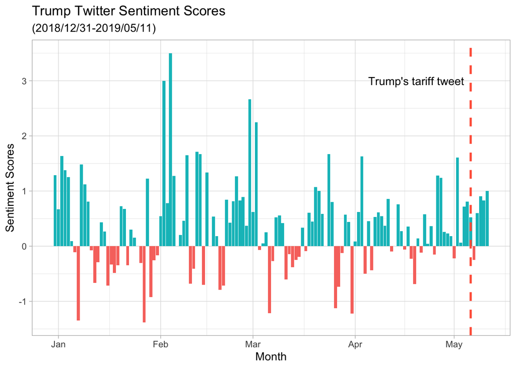

```r
trump_plot_afinn <- trump_twitter %>%
  # 因為有些編碼問題，先確認全部轉為 UTF-8
  mutate(text = str_conv(text, encoding = "UTF-8")) %>%
  # 斷詞
  tidytext::unnest_tokens(input = text, output = word) %>%
  # 加入情緒分數，因為使用inner_join，所以沒有在情緒辭典的字都會直接刪除
  inner_join(afinn_dict, by = "word") %>%
  # 以日期分群
  group_by(date) %>%
  # 計算每日的情緒分數
  summarize(day_score_avg = mean(value),
         # 製作一個新欄位，呈現當天是正面或負面情緒
         is_pos = if_else(day_score_avg > 0, TRUE, FALSE)) %>%
  ungroup()

# 將剛整理好的資料畫圖看看
ggplot(trump_plot_afinn, aes(x = date, y = day_score_avg)) +
  geom_col(aes(fill = is_pos), show.legend = FALSE) +
  theme_light() +
  labs(x = "Month", y = "Sentiment Scores",
       title = "Trump Twitter Sentiment Scores",
       subtitle = "(2018/12/31-2019/05/11)") +
  # 畫一條垂直線
  geom_vline(xintercept = as.Date("2019-05-06"),
             linetype = "dashed", color = "tomato", size = 1) +
  # 註記要標示的文字及相關設定
  ggplot2::annotate(geom = "text",
           # x, y 的定位點
           x = as.Date("2019-05-04"),
           y = 3,
           label = "Trump's tariff tweet",
           # 靠右對齊
           hjust = 1)
```

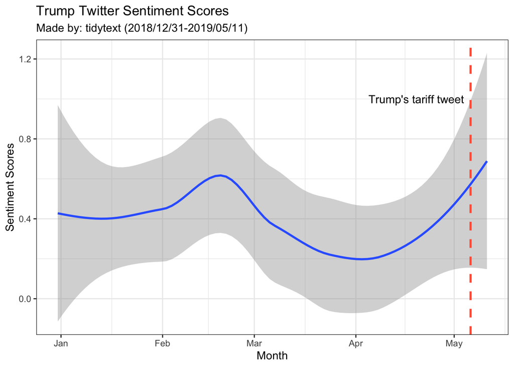

```r
# 另一種呈現方式
(p1 <- ggplot(trump_plot_afinn, aes(x = date, y = day_score_avg)) +
  geom_smooth() + # se = FALSE 可以設定不要灰底的信賴區間（預設0.95）
  theme_bw() +
  # 畫一條垂直線
  geom_vline(xintercept = as.Date("2019-05-06"),
             linetype = "dashed", color = "tomato", size = 1) +
  # 註記要標示的文字及相關設定
  ggplot2::annotate(geom = "text",
           # x, y 的定位點
           x = as.Date("2019-05-04"),
           y = 1,
           label = "Trump's tariff tweet",
           # 靠右對齊
           hjust = 1) +
  labs(x = "Month", y = "Sentiment Scores", title = "Trump Twitter Sentiment Scores", subtitle = "Made by: tidytext (2018/12/31-2019/05/11)"))
```

有了各種情緒標記，可以依照你的研究問題，使用不同的情緒辭典做出各種不同的分析，但**關鍵的還是想出一個有趣的研究問題，並用適合的文字資料與方法來回應你提出來的問題**，切勿本末倒置。

我們來試試看另一種計算的方式，將每日的正面情緒與負面情緒分數都算出來，然後分別畫出來。

```r
trump_afinn_pos_neg <- trump_twitter %>%
  # 因為有些編碼問題，先確認全部轉為 UTF-8
  mutate(text = str_conv(text, encoding = "UTF-8")) %>%
  # 斷詞
  tidytext::unnest_tokens(input = text, output = word) %>%
  # 加入情緒分數，因為使用inner_join，所以沒有在情緒辭典的字都會直接刪除
  inner_join(afinn_dict, by = "word") %>%
  # 製作一個新的欄位，標示出是正面與負面情緒
  mutate(pos_neg = if_else(value > 0, true = "positive",
                           false = "negative")) %>%
  # 依照日期與正負面情緒分群
  group_by(date, pos_neg) %>%
  # 計算各日的正負面情緒分群的平均數
  summarize(day_score_avg = mean(value)) %>%
  ungroup()
```

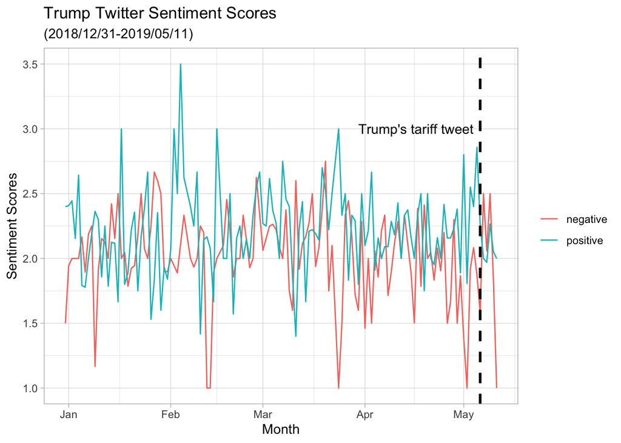

```r
# 將剛整理好的資料畫圖看看
ggplot(trump_afinn_pos_neg, aes(x = date, y = abs(day_score_avg))) + # 要將day_score_avg轉換為絕對值，會比較好比較。
  geom_line(aes(color = pos_neg)) +
  theme_light() +
  theme(legend.title = element_blank()) +
  labs(x = "Month", y = "Sentiment Scores",
       title = "Trump Twitter Sentiment Scores",
       subtitle = "(2018/12/31-2019/05/11)") +
  # 畫一條垂直線
  geom_vline(xintercept = as.Date("2019-05-06"),
             linetype = "dashed", color = "black", size = 1) +
  # 註記要標示的文字及相關設定
  ggplot2::annotate(geom = "text",
           # x, y 的定位點
           x = as.Date("2019-05-04"),
           y = 3,
           label = "Trump's tariff tweet",
           # 靠右對齊
           hjust = 1)
```

## 練習

使用`trump_twitter`資料，並運用`nrc_dict`情緒辭典分析這段時間川普推特的情緒發展。

1. 將情緒辭典資料併入
2. 篩選兩個較為對立的情緒
3. 計算每日發生各種情緒的字數
4. 將依照labs的資訊，填入正確的x, y
5. 依照不同的情緒，畫成不同顏色的線段

```r
trump_twitter %>%
  # 斷詞
  tidytext::unnest_tokens(input = text, output = word) %>%
  # 加入情緒類別，因為使用xxxxx_join，所以沒有在情緒辭典的字都會直接刪除
  _________(___________, by = "word") %>%
  # 篩選其中兩種比較對立的情緒來呈現
  filter(____________________) %>%
  # 計算每日發生該種情緒的字數
  ________(date, sentiment) %>%
  # 開始畫圖，請依照後面的資訊，填入正確的x, y
  ggplot(aes(x = ________, y = _________)) +
  # 將不同情緒以不同顏色區分
  geom_line(aes(______________), size = 1) +
  # 再畫一條趨勢線
  geom_smooth(se = FALSE) +
  theme_minimal() +
  scale_color_brewer(type = "qual") +
  labs(x = "Month", y = "sentiment count", title = "Trump's mood via twitter", subtitle = "(2019)") # +
  # facet_wrap(~ sentiment, nrow = 1)
```

除了`textdata`提供的情緒辭典外，也有很多可以進行情緒分析的套件。以下再介紹一個可以處理句子（sentence）與脈絡的情緒分析套件`sentimentr`。

```r
(mytext <- tibble(text = c(
  "do you like it?  But I hate really bad dogs",
  "I am the best friend.",
  "Do you really like it?  I\'m not a fan"))
)
```

```
## # A tibble: 3 × 1
##   text
##   <chr>
## 1 do you like it?  But I hate really bad dogs
## 2 I am the best friend.
## 3 Do you really like it?  I'm not a fan
```

```r
# the example of the output
get_sentences(mytext) %>%
  sentiment()
```

```
##                          text element_id sentence_id word_count  sentiment
## 1:            do you like it?          1           1          4  0.2500000
## 2: But I hate really bad dogs          1           2          6 -1.8677359
## 3:      I am the best friend.          2           1          5  0.5813777
## 4:     Do you really like it?          3           1          5  0.4024922
## 5:              I'm not a fan          3           2          4  0.0000000
```

```r
get_sentences(mytext) %>%
  # 依不同文件group_by，會多計算標準差
  sentiment_by(by = "element_id")
```

```
##    element_id word_count       sd ave_sentiment
## 1:          1         10 1.497465    -0.8088680
## 2:          2          5       NA     0.5813777
## 3:          3          9 0.284605     0.2196345
```

在瞭解了基本的操作邏輯後，讓我們實際用在trump_twitter看看結果會有什麼不同。

```r
# 單純以句子為斷詞，並計算每句情緒分數
trump_twitter %>%
  # 因為有些編碼問題，先確認全部轉為 UTF-8
  mutate(text = str_conv(text, encoding = "UTF-8")) %>%
  # 以每句為斷詞單位
  sentimentr::get_sentences() %>%
  # 以每句為單位計算情緒分數
  sentimentr::sentiment()
```

```
##                                                                                                                                           text
##    1:                                                                                                       Such an easy way to avoid Tariffs?
##    2:                                                                             Make or produce your goods and products in the good old USA.
##    3:                                                                                                                       It?�s very simple!
##    4:            Military spouses share an admirable legacy of unwavering devotion to their loved ones in uniform and to the cause of freedom.
##    5:                   On Military Spouse Day we honor our Nation?�s military spouses and express our deep appreciation for all that they do!
##   ---
## 3425: These are people who have been approved by committees and all others yet Schumer continues to hold them back from serving their Country!
## 3426:                                                                                                                             Very Unfair!
## 3427:               Heads of countries are calling wanting to know why Senator Schumer is not approving their otherwise approved Ambassadors!?
## 3428:                                                            Likewise in Government lawyers and others are being delayed at a record pace!
## 3429:                                                                       360 great and hardworking people are waiting for approval from....
##             date retweet_count favorite_count element_id sentence_id word_count
##    1: 2019-05-11         29478         133624          1           1          7
##    2: 2019-05-11         29478         133624          1           2         12
```

[output cut: 21 more lines]

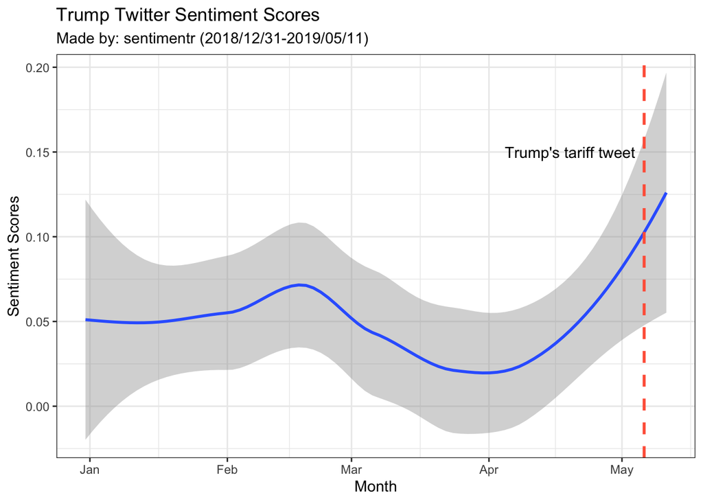

```r
# 以句子為斷詞，然後以每日分群，計算出平均情緒分數與標準差
(p2 <- trump_twitter %>%
  # 因為有些編碼問題，先確認全部轉為 UTF-8
  mutate(text = str_conv(text, encoding = "UTF-8")) %>%
  # 以每句為斷詞單位
  sentimentr::get_sentences() %>%
  # 以每日分群，再以每句為單位計算情緒分數，再求平均數與標準差
  sentimentr::sentiment_by(by = "date") %>%
  ggplot(aes(x = date, y = ave_sentiment)) +
  geom_smooth() +
  theme_bw() +
  # 畫一條垂直線
  geom_vline(xintercept = as.Date("2019-05-06"),
             linetype = "dashed", color = "tomato", size = 1) +
  # 註記要標示的文字及相關設定
  ggplot2::annotate(geom = "text",
           # x, y 的定位點
           x = as.Date("2019-05-04"),
           y = 0.15,
           label = "Trump's tariff tweet",
           # 靠右對齊
           hjust = 1) +
  labs(x = "Month", y = "Sentiment Scores", title = "Trump Twitter Sentiment Scores", subtitle = "Made by: sentimentr (2018/12/31-2019/05/11)"))
```

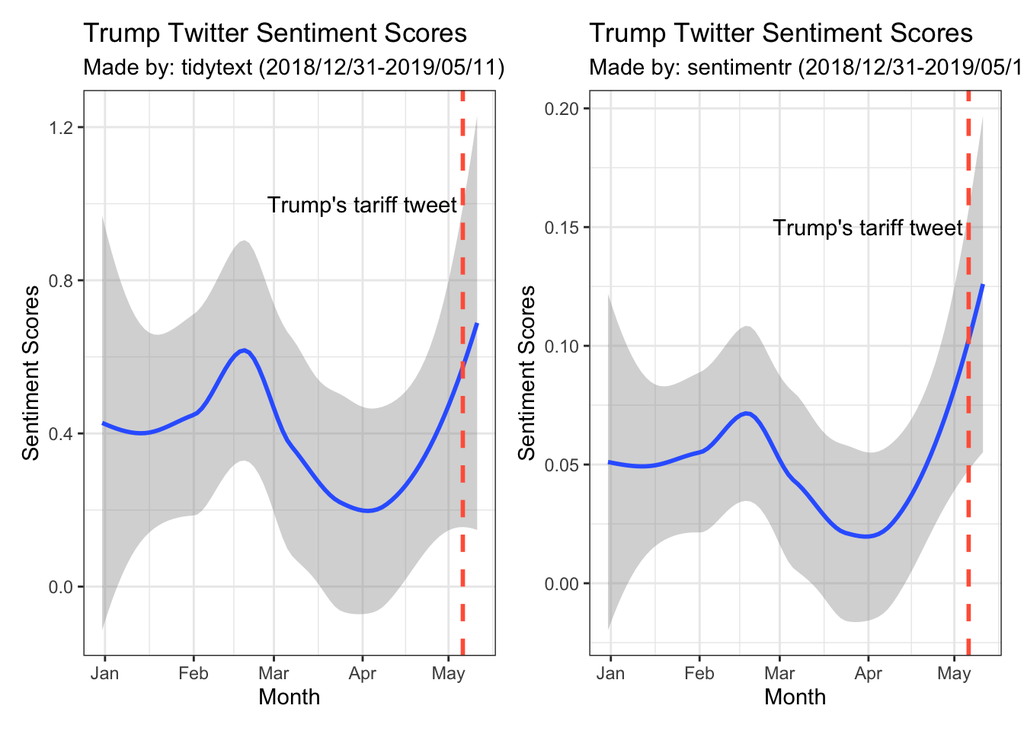

```r
# 在分別以每字為基礎的tidytext與每句為基礎的sentimentr計算出每日不同的情緒分數，現在把兩張圖拼在一起看看結果有何差異。
library(patchwork)
p1 + p2
```

實際上來看，其實整體趨勢的落差不大！但要注意兩圖y軸的情緒分數scale差距不小。

## 3. 中文情緒辭典

中文的情緒分析操作起來跟英文的其實做法一樣，同樣是斷詞後將情緒辭典標註併入原本的語料中。這裡使用的是中研院所研發的中文情緒辭典，有興趣的同學可以參考這個網址： [Natural Language and Knowledge Processing Lab, Institute of Information Science, Academia Sinica](http://academiasinicanlplab.github.io/)

```r
# 正面情緒辭典
pos_dict <- readr::read_delim(file = "data/NTUSD_positive_unicode.txt",
                              delim = "\n", col_names = FALSE) %>%
  mutate(sentiment = "positive") %>%
  rename(word = X1)

# 負面情緒辭典
neg_dict <- readr::read_delim(file = "data/NTUSD_negative_unicode.txt",
                              delim = "\n", col_names = FALSE) %>%
  mutate(sentiment = "negative") %>%
  rename(word = X1)

# 將兩者併在一起
zh_dict <- pos_dict %>%
  bind_rows(neg_dict)

zh_dict %>%
  group_by(sentiment) %>%
  summarize(n = n())
```

```
## # A tibble: 2 × 2
##   sentiment     n
##   <chr>     <int>
## 1 negative   8274
## 2 positive   2810
```

我們使用先前用過的審計部新聞公告，來看看其情緒趨勢。（就作業四的分析結果，可以先猜看看可能會是什麼樣的趨勢）

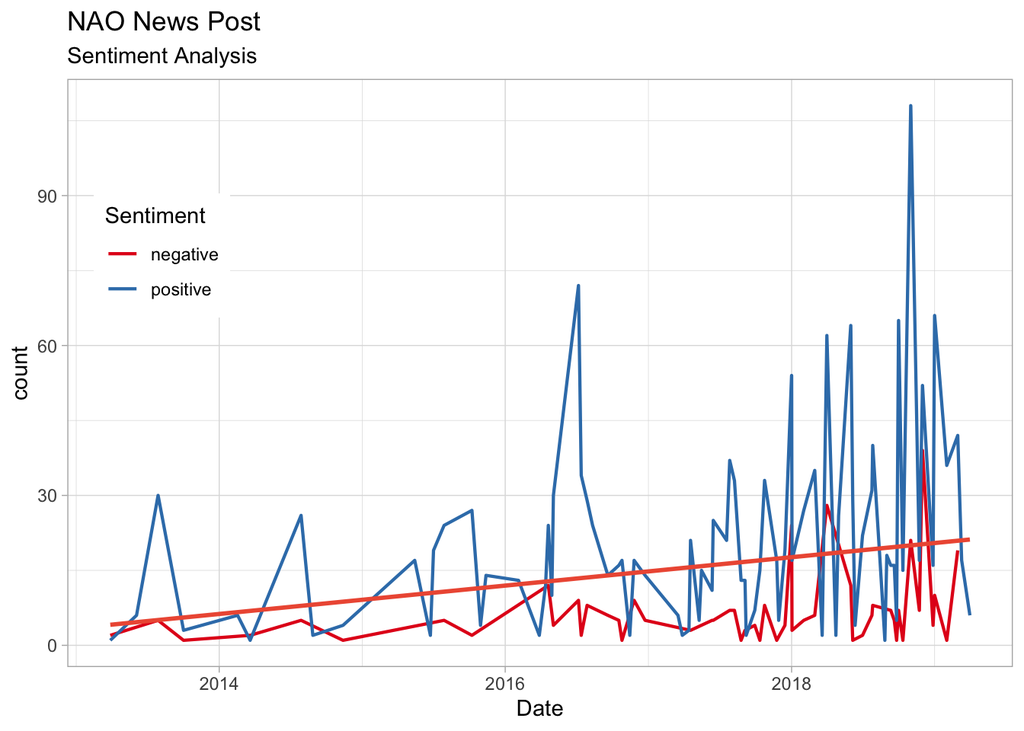

```r
# 讀取RData檔
load("data/nao.RData") # 讀入的資料為data_all

# 建立斷詞引擎
seg_engine <- worker(bylines = TRUE)

nao_data <- data_all %>%
  mutate(token = segment(fulltext, jiebar = seg_engine)) %>%
  unnest(token) %>%
  mutate(date = lubridate::ymd(date)) %>%
  select(date, token) %>%
  inner_join(zh_dict, by = c("token" = "word")) %>%
  count(date, sentiment)

ggplot(nao_data, aes(x = date, y = n)) +
  geom_line(aes(color = sentiment), size = 0.75) +
  geom_smooth(color = "tomato2", method = "lm", se = FALSE) +
  scale_color_brewer(type = "qual", palette = 6) +
  theme_light() +
  labs(x = "Date", y = "count", title = "NAO News Post", subtitle = "Sentiment Analysis", color = "Sentiment") +
  # scale_y_sqrt() +
  # 手動調整legend的位置到圖內
  theme(legend.position = c(0.1, 0.7))
```

# 其他資料

[LIWC](https://cliwc.weebly.com/) [Moral Foundation Dictionary 2.0](https://osf.io/ezn37/) [增廣中文意見詞詞典（AUTUSD）](https://docs.google.com/forms/d/e/1FAIpQLSe2Bx1CYqLajfthIL8Q_32HXHqWrxkJMc6f9AnsVuxTD4BdGg/viewform?c=0&w=1)：AUTUSD為經過情感標記蒐集的字詞情感統計數據所匯聚而成的情感辭典，共有26,021個詞彙。每個字都提供了情緒分數和正面標記、中立標記、負面標記、非意見詞標記及非詞標記的數量。

# 讀入外部辭典的其他方式

以下是示範使用`quanteda`的方式讀入辭典資料，但因為使用`quanteda`後續分析的做法與`tidytext`的方式截然不同，這裡就不多做介紹，但很建議有興趣的同學試試。

```r
library(quanteda)
mfd2 <- quanteda::dictionary(file = "data/mfd2.dic")
```